# Visual Story about my YouTube Journey Habits

Allen Vong

## Context ?

I’ve been wondering what would be an interesting “story” about myself I could tell through data visualization. And then it suddenly clicked when I was searching for a certain content that I saved for later through my search history.

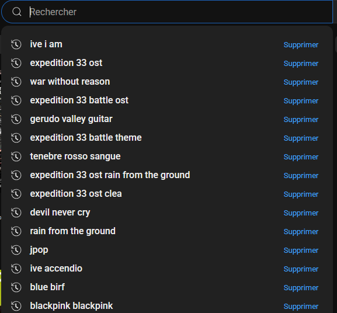

A peek at my search history

I went through Google Takeout to look at my watch history and wanted to record my YouTube history starting from the beginning of the year and record the “phase” I went through.

My thought process was that it would be informative to know what were the major type of contents for each months.

That’s why I recorded in my Google form the videos I watched each month: the contents, the channel’s name, the months I watched it, the title, the length and my reason for watching it.

## Surprising contents ?!

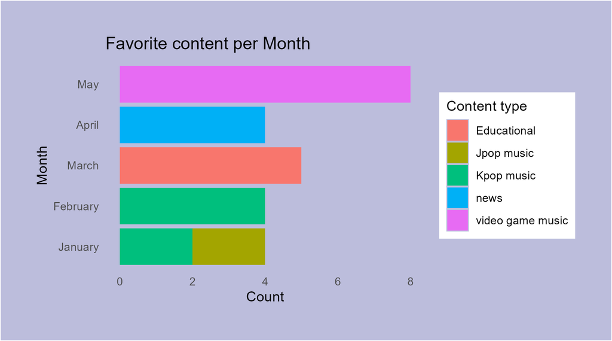

I was quite surprised to note that the major contents I watched were not the ones I was expecting. I was expecting to see video game gameplay and entertainment as the major themes for each months, as I watched a lot of french entertainment and people playing games.

The plot above shows the my favorite content starting from the start of the year and when I think about it more it does make more sense as I usually listen to music on YouTube for approximately 70% of the time and the rest are for entertaining french videos.

## Immaculated music taste (as expected)

From the reflection above I was curious about the language of the music I was listening to and for this plot I was pleasantly surprised that my expectations were met.

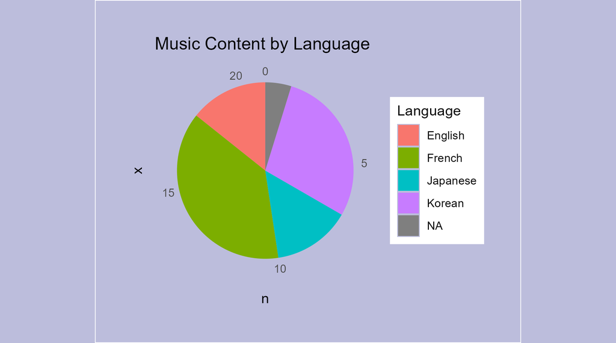

Overall these months, I remembered blasting kpop through my ears when I was at my internship, I remembered getting back from part-time work to then watch educational coding and language videos and I remembered listening to lots of french song when I was homesick.

## At least Half ???

Talking about songs, it seems that half of my logging data is about music.

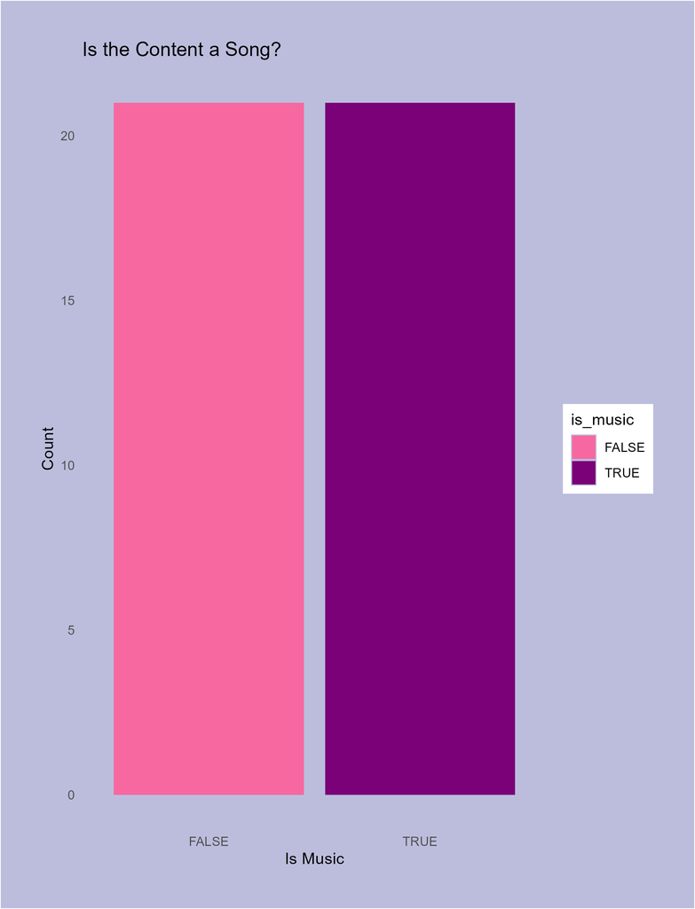

summerized content of song

## Viva la France!

Unsurprisingly, I watched a lot of french contents as it is my main language. That’s why I want to know what were the main contents in my french repertoire.

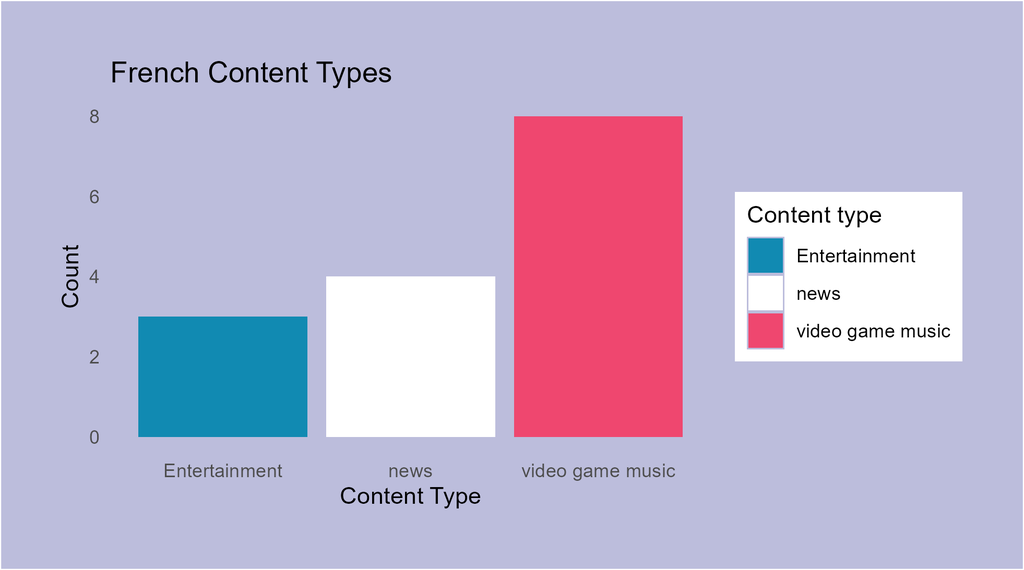

french content types

The observation above showed that I watched more contents about the news around the world in french than french entertaining contents, It could be explained by the fact that most of the entertainment is long-format whereas the news are medium-format.

[figure not shown]